# Practical Machine Learning - Programming Assignment

# Executive Summary

The goal of this assignment is to predict the manner in which 6 individuals did exercise using data from accelerometers. Any variables of the data set can be used in order to build the prediction model. The resulting prediction model shall be used to predict the outcome “classe” for 20 different test cases.

In order to predict the model, first we split the training set into a training and a validation dataset. Then we proceed to clean the data, that is, we check if there are any superfluous measurements in the training set. For example we delete all variables with a NA proportion over 60%. Moreover we look into the class of the variables. All modifications carried out in the training set, will also be applied to the validation and testing sets.

Finally we build a prediction model on the training set and evaluate its performance on the validation set before we apply it to the 20 test cases of the testing set. We compare the accuracy of three different prediction algorithms: decision trees, random forest and boosted regression.

Since the prediction model based on random forest algorithm is the one with the greatest overall accuracy, it will applied to predict the outcome of the testing set.

# Getting and cleaning data

First of all, we load all the packages we will need into our library:

```r
library(caret)
library(rpart)
library(rpart.plot)
library(rattle)
library(randomForest)
library(corrplot)
```

Next we download the data from the url made available in the task description and read the data into R. Note that when reading the datai into R we will set certain character strings to NA.

```r
# Link for data
urltrain <- "http://d396qusza40orc.cloudfront.net/predmachlearn/pml-training.csv"
urltest <- "http://d396qusza40orc.cloudfront.net/predmachlearn/pml-testing.csv"

download.file(urltrain, "D:/Data Science/Practical machine learning/Exercises/Programming_Assignment/Raw_data/pml-training.csv")
download.file(urltest, "D:/Data Science/Practical machine learning/Exercises/Programming_Assignment/Raw_data/pml-testing.csv")

pmltraining <- read.csv("D:/Data Science/Practical machine learning/Exercises/Programming_Assignment/Raw_data/pml-training.csv",
    dec = ".", sep = ",", header = TRUE, stringsAsFactors = FALSE,
    na.strings = c("NA", "", "#DIV/0!"))
pmltesting <- read.csv("D:/Data Science/Practical machine learning/Exercises/Programming_Assignment/Raw_data/pml-testing.csv",
    dec = ".", sep = ",", header = TRUE, stringsAsFactors = FALSE,
    na.strings = c("NA", "", "#DIV/0!"))
```

The training set will be split into training and validation set. The testing data set includes the 20 test cases for which we are to predict how the exercise was carried out.The resulting training test includes 11776 observations while the validation set includes 7846 observations.

```r
set.seed(23466)
intrain <- createDataPartition(pmltraining$classe, p = 0.6, list = FALSE)
training <- pmltraining[intrain, ]
validation <- pmltraining[-intrain, ]

dim(training)
```

```
## [1] 11776   160
```

```r
dim(validation)
```

```
## [1] 7846  160
```

Next we need to clean the training set and apply the modifications to the validation and test sets. First we delete the first column, since this is just the observation/row identifier. Then we only keep dimensions (columns) where the proportion of NAs is less than 60 percent.

```r
training <- training[, -1]
numNA <- do.call(rbind, lapply(1:(dim(training)[2]), function(i) {
    sum(is.na(training[, i]))
}))
propNA <- numNA/(dim(training)[1])
training2 <- training[, which(propNA < 0.6)]
```

Next we check if there are any variables with near zero variables. Only the variable “new_window” is identified as one. This is a categorical variable with two levels. I decided not to delete this variable from the set of potential predictors.

```r
nzvar <- nearZeroVar(training2, saveMetrics = TRUE)
colnames(training2)[nzvar$nzv == TRUE]
```

```
## [1] "new_window"
```

```r
table(training2[, "new_window"])  #factor variable with two levels. I wont delete it
```

```
##
##    no   yes
## 11514   262
```

Since we have already deleted some measurements from the training set, we need to make sure that these variables are also droped in the the validation and testing sets.

```r
# validation and testing set, should have exactly the same
# variables
validation2 <- validation[, which(colnames(validation) %in% colnames(training2))]
testing <- pmltesting[, which(colnames(pmltesting) %in% colnames(training2))]
```

Next we check the class of the variables of the training set and select out those which are not integer or numeric. The variables classe, username and newwindow are turned into factor variables. The variable cvtd_timestamp is turned into a date-variable and than forced into integer class. These modifications of the class of the variables of the training set is applied to the validation and testing sets.

```r
class <- do.call(rbind, lapply(1:(dim(training2)[2]), function(x) {
    cl <- class(training2[, x])
}))
table(class)
```

```
## class
## character   integer   numeric
##         4        28        27
```

```r
colsindx <- which(class != "integer" & class != "numeric")  #index of variables which are neither numeric nor integer
View(head(training2[, colsindx]))
str(training2[, colsindx])
```

```
## 'data.frame':    11776 obs. of  4 variables:
##  $ user_name     : chr  "carlitos" "carlitos" "carlitos" "carlitos" ...
##  $ cvtd_timestamp: chr  "05/12/2011 11:23" "05/12/2011 11:23" "05/12/2011 11:23" "05/12/2011 11:23" ...
##  $ new_window    : chr  "no" "no" "no" "no" ...
##  $ classe        : chr  "A" "A" "A" "A" ...
```

```r
# Analyse these variables, should their class be transformed?
table(training2$classe)  #5 levels, turn into a factor variable
```

```
##
##    A    B    C    D    E
## 3348 2279 2054 1930 2165
```

```r
table(training2$user_name)  #6 levels, these are names, turn also into a factor variable
```

```
##
##   adelmo carlitos  charles   eurico   jeremy    pedro
##     2317     1900     2126     1861     2046     1526
```

```r
table(training2$new_window)  # 2 levels, tur also into a factor variable
```

```
##
##    no   yes
## 11514   262
```

```r
# cvtd_timestamp should be change into date format and than
# numeric

# Change the class of the variables
training3 <- training2
training3$cvtd_timestamp <- as.integer(as.numeric(strptime(training3$cvtd_timestamp,
    format = "%d/%m/%Y %H:%M")))
training3$classe <- as.factor(training3$classe)
training3$user_name <- as.factor(training3$user_name)
training3$new_window <- as.factor(training3$new_window)
str(training3)
```

```
## 'data.frame':    11776 obs. of  59 variables:
##  $ user_name           : Factor w/ 6 levels "adelmo","carlitos",..: 2 2 2 2 2 2 2 2 2 2 ...
##  $ raw_timestamp_part_1: int  1323084231 1323084232 1323084232 1323084232 1323084232 1323084232 1323084232 1323084232 1323084232 1323084232 ...
##  $ raw_timestamp_part_2: int  808298 440390 484323 484434 528316 576390 692324 876301 892313 932285 ...
##  $ cvtd_timestamp      : int  1323080580 1323080580 1323080580 1323080580 1323080580 1323080580 1323080580 1323080580 1323080580 1323080580 ...
##  $ new_window          : Factor w/ 2 levels "no","yes": 1 1 1 1 1 1 1 1 1 1 ...
##  $ num_window          : int  11 12 12 12 12 12 12 12 12 12 ...
##  $ roll_belt           : num  1.41 1.42 1.43 1.45 1.43 1.42 1.51 1.6 1.57 1.56 ...
##  $ pitch_belt          : num  8.07 8.13 8.16 8.17 8.18 8.21 8.12 8.1 8.09 8.1 ...
##  $ yaw_belt            : num  -94.4 -94.4 -94.4 -94.4 -94.4 -94.4 -94.4 -94.4 -94.4 -94.3 ...
##  $ total_accel_belt    : int  3 3 3 3 3 3 3 3 3 3 ...
##  $ gyros_belt_x        : num  0.02 0.02 0.02 0.03 0.02 0.02 0 0.02 0.02 0.02 ...
##  $ gyros_belt_y        : num  0 0 0 0 0 0 0 0 0.02 0 ...
##  $ gyros_belt_z        : num  -0.02 -0.02 -0.02 0 -0.02 -0.02 -0.02 -0.02 -0.02 -0.02 ...
##  $ accel_belt_x        : int  -22 -22 -20 -21 -22 -22 -21 -20 -21 -21 ...
```

[output cut: 45 more lines]

```r
# Apply the class transformation to the validation and
# testing data sets
validation3 <- validation2
validation3$cvtd_timestamp <- as.integer(as.numeric(strptime(validation3$cvtd_timestamp,
    format = "%d/%m/%Y %H:%M")))
validation3$classe <- as.factor(validation3$classe)
validation3$user_name <- factor(validation3$user_name, levels = levels(training3[,
    "user_name"]))
validation3$new_window <- factor(validation3$new_window, levels = levels(training3[,
    "new_window"]))
testing2 <- testing
testing2$cvtd_timestamp <- as.integer(as.numeric(strptime(testing2$cvtd_timestamp,
    format = "%d/%m/%Y %H:%M")))
testing2$user_name <- factor(testing2$user_name, levels = levels(training3[,
    "user_name"]))
testing2$new_window <- factor(testing2$new_window, levels = levels(training3[,
    "new_window"]))
```

Next we check the correlation between the different time-variales available in the training set, i.e. rawtimestamppart1, rwatimestamppart2 and cvtdtimestamp. Since the correlation between rawtimestamppart1 and cvstdtimestamp is 1, the latter will be deleted from the training set. Recall that we turned cvstdtimestamp was a character variable, that we turned in to date format and than into numeric. This information seems to already have been included in the variable rawtimestamppart1, an originally numeric variable.

```r
corrmat <- cor(training3[, 2:4])
# Correlation between raw_timestamp_part_1 and cvtd_timestamp
# is 1.
fin_training <- training3[, -which(colnames(training3) == "cvtd_timestamp")]
fin_validation <- validation3[, -which(colnames(validation3) ==
    "cvtd_timestamp")]
fin_testing <- testing2[, -which(colnames(testing2) == "cvtd_timestamp")]
```

The final training and validation data sets include 58 variables, the testing set includes only 57 variables since the outcome variable “classe” in not included.

```r
dim(fin_training)
```

```
## [1] 11776    58
```

```r
dim(fin_validation)
```

```
## [1] 7846   58
```

```r
dim(fin_testing)
```

```
## [1] 20 57
```

# Building the prediction model

## Prediction with decision tree

First we use a decision tree to fit a model for predicting the outcome in out training set. The resulting decision tree is plotted using the command fancyRpartPlot. Moreover we check the variable importance.

```r
set.seed(12345)
moddtree <- rpart(classe ~ ., data = fin_training, method = "class")
varImp(moddtree, useModel = TRUE)
```

```
##                      Overall
## accel_arm_x              342
## accel_belt_z             556
## accel_dumbbell_y        1100
## accel_dumbbell_z         400
## accel_forearm_x          413
## accel_forearm_y           52
## gyros_arm_x              102
## gyros_belt_z             204
## magnet_arm_x             458
## magnet_arm_y             126
## magnet_belt_x             75
## magnet_belt_y            620
## magnet_belt_z            105
## magnet_dumbbell_x         84
## magnet_dumbbell_y        940
## magnet_dumbbell_z       1514
## magnet_forearm_y         205
## magnet_forearm_z         405
## num_window              2271
## pitch_belt              1046
## pitch_dumbbell           459
## pitch_forearm           1654
## raw_timestamp_part_1    3346
## roll_belt               1522
## roll_dumbbell            521
## roll_forearm            1644
## total_accel_belt         542
## total_accel_dumbbell     232
## yaw_belt                 747
## yaw_dumbbell             292
## yaw_forearm              111
## user_name                  0
## raw_timestamp_part_2       0
## new_window                 0
## gyros_belt_x               0
## gyros_belt_y               0
## accel_belt_x               0
## accel_belt_y               0
## roll_arm                   0
## pitch_arm                  0
## yaw_arm                    0
## total_accel_arm            0
## gyros_arm_y                0
## gyros_arm_z                0
## accel_arm_y                0
## accel_arm_z                0
## magnet_arm_z               0
## gyros_dumbbell_x           0
## gyros_dumbbell_y           0
## gyros_dumbbell_z           0
## accel_dumbbell_x           0
## total_accel_forearm        0
## gyros_forearm_x            0
## gyros_forearm_y            0
## gyros_forearm_z            0
## accel_forearm_z            0
## magnet_forearm_x           0
```

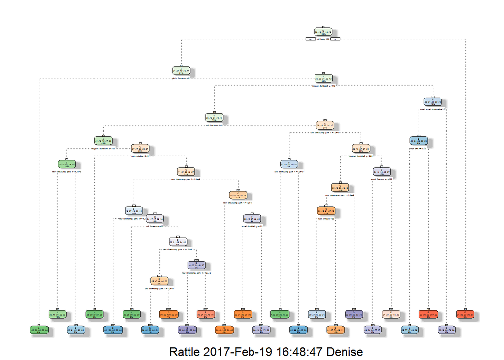

```r
fancyRpartPlot(moddtree)
```

Next we apply the prediction algorithm to the validation set and obtain the confusion matrix. According to the output of the confusion matrix, the decision tree prediction algorithm has an overall accuracy of 0.816 in the validation data set.

```r
preddtree <- predict(moddtree, fin_validation, type = "class")
conmatdtree <- confusionMatrix(preddtree, fin_validation$classe)
conmatdtree
```

```
## Confusion Matrix and Statistics
##
##           Reference
## Prediction    A    B    C    D    E
##          A 2061  147   12   39   76
##          B   79 1083   42   84  102
##          C   10   83 1198   74  114
##          D   46   97   29  992   80
##          E   36  108   87   97 1070
##
## Overall Statistics
##
##                Accuracy : 0.816
##                  95% CI : (0.807, 0.825)
##     No Information Rate : 0.284
##     P-Value [Acc > NIR] : < 2e-16
##
##                   Kappa : 0.767
##  Mcnemar's Test P-Value : 4.81e-12
##
## Statistics by Class:
##
##                      Class: A Class: B Class: C Class: D Class: E
## Sensitivity             0.923    0.713    0.876    0.771    0.742
## Specificity             0.951    0.951    0.957    0.962    0.949
## Pos Pred Value          0.883    0.779    0.810    0.797    0.765
## Neg Pred Value          0.969    0.933    0.973    0.955    0.942
## Prevalence              0.284    0.193    0.174    0.164    0.184
## Detection Rate          0.263    0.138    0.153    0.126    0.136
## Detection Prevalence    0.298    0.177    0.189    0.159    0.178
## Balanced Accuracy       0.937    0.832    0.916    0.866    0.845
```

Next we plot the results of the confusion matrix.

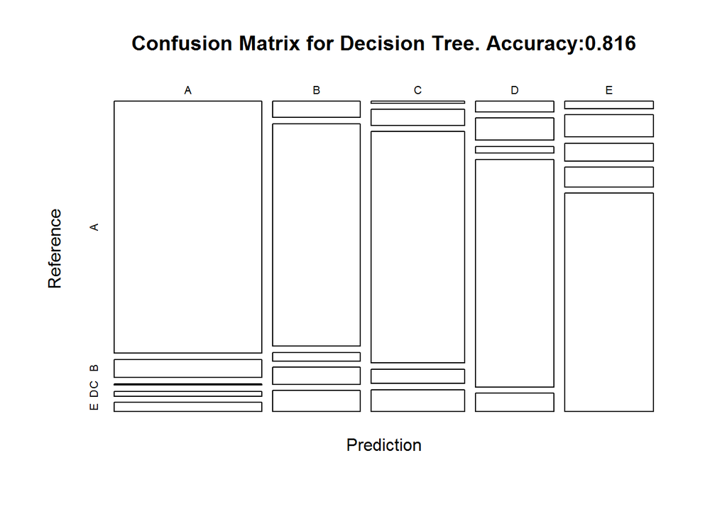

```r
plot(conmatdtree$table, col = conmatdtree$byClass, main = paste0("Confusion Matrix for Decision Tree. Accuracy:",
    round(conmatdtree$overall["Accuracy"], 3)))
```

## Prediction with Random Forest

Next we use random forest to build a prediction algorithm on the training set and obtain the variance importance.

```r
set.seed(12345)
modrf <- randomForest(classe ~ ., data = fin_training)
varImp(modrf, useModel = TRUE)
```

```
##                      Overall
## user_name               87.8
## raw_timestamp_part_1  1099.5
## raw_timestamp_part_2    13.7
## new_window               0.2
## num_window             649.3
## roll_belt              606.5
## pitch_belt             329.4
## yaw_belt               418.2
## total_accel_belt       127.8
## gyros_belt_x            45.2
## gyros_belt_y            58.3
## gyros_belt_z           137.6
## accel_belt_x            64.3
## accel_belt_y            67.6
## accel_belt_z           222.5
## magnet_belt_x          126.6
## magnet_belt_y          214.2
## magnet_belt_z          202.7
## roll_arm               146.3
## pitch_arm               79.3
## yaw_arm                108.6
## total_accel_arm         41.7
## gyros_arm_x             55.1
## gyros_arm_y             54.8
## gyros_arm_z             24.5
## accel_arm_x            118.8
## accel_arm_y             65.5
## accel_arm_z             60.2
## magnet_arm_x           120.3
## magnet_arm_y           103.6
## magnet_arm_z            73.4
## roll_dumbbell          224.4
## pitch_dumbbell          89.0
## yaw_dumbbell           132.4
## total_accel_dumbbell   128.0
## gyros_dumbbell_x        52.5
## gyros_dumbbell_y       112.7
## gyros_dumbbell_z        32.7
## accel_dumbbell_x       133.7
## accel_dumbbell_y       196.8
## accel_dumbbell_z       166.8
## magnet_dumbbell_x      245.4
## magnet_dumbbell_y      349.8
## magnet_dumbbell_z      388.9
## roll_forearm           293.3
## pitch_forearm          377.6
## yaw_forearm             74.4
## total_accel_forearm     42.1
## gyros_forearm_x         33.0
## gyros_forearm_y         51.4
## gyros_forearm_z         36.8
## accel_forearm_x        157.8
## accel_forearm_y         57.0
## accel_forearm_z        103.1
## magnet_forearm_x        96.7
## magnet_forearm_y        95.1
## magnet_forearm_z       116.0
```

Next we apply the random forest prediction algorithm on the validation set and obtain the confusion matrix. We plot the results. The overall accuracy of the random forest prediction algorithm on the validation set is 0.999.

```r
predrf <- predict(modrf, fin_validation, type = "response")
conmatrf <- confusionMatrix(predrf, fin_validation$classe)
conmatrf
```

```
## Confusion Matrix and Statistics
##
##           Reference
## Prediction    A    B    C    D    E
##          A 2232    2    0    0    0
##          B    0 1516    1    0    0
##          C    0    0 1367    4    0
##          D    0    0    0 1281    2
##          E    0    0    0    1 1440
##
## Overall Statistics
##
##                Accuracy : 0.999
##                  95% CI : (0.998, 0.999)
##     No Information Rate : 0.284
##     P-Value [Acc > NIR] : <2e-16
##
##                   Kappa : 0.998
##  Mcnemar's Test P-Value : NA
##
## Statistics by Class:
##
##                      Class: A Class: B Class: C Class: D Class: E
## Sensitivity             1.000    0.999    0.999    0.996    0.999
## Specificity             1.000    1.000    0.999    1.000    1.000
## Pos Pred Value          0.999    0.999    0.997    0.998    0.999
## Neg Pred Value          1.000    1.000    1.000    0.999    1.000
## Prevalence              0.284    0.193    0.174    0.164    0.184
## Detection Rate          0.284    0.193    0.174    0.163    0.184
## Detection Prevalence    0.285    0.193    0.175    0.164    0.184
## Balanced Accuracy       1.000    0.999    0.999    0.998    0.999
```

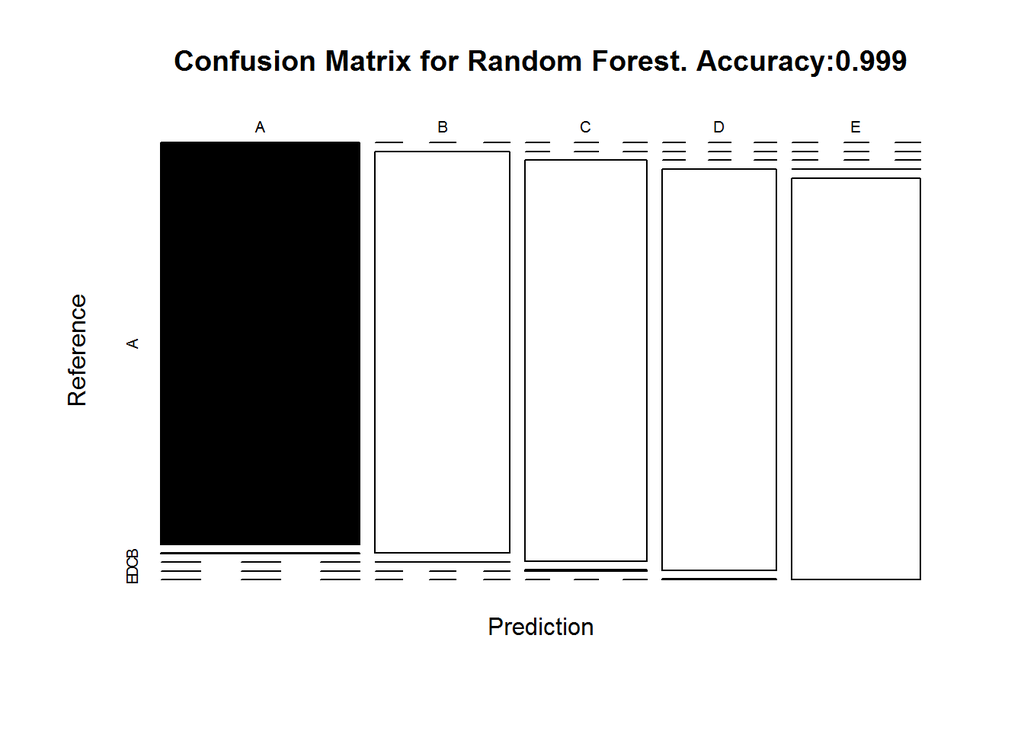

```r
plot(conmatrf$table, col = conmatrf$byClass, main = paste0("Confusion Matrix for Random Forest. Accuracy:",
    round(conmatrf$overall["Accuracy"], 3)))
```

## Prediction with Generalized Boosted Regression

Next and last we build a prediction algorithm using boosted regression.

```r
set.seed(12345)
fitControl <- trainControl(method = "repeatedcv", number = 5,
    repeats = 1)
modgbm <- train(classe ~ ., data = fin_training, method = "gbm",
    trControl = fitControl, verbose = FALSE)
modgbm
```

```
## Stochastic Gradient Boosting
##
## 11776 samples
##    57 predictor
##     5 classes: 'A', 'B', 'C', 'D', 'E'
##
## No pre-processing
## Resampling: Cross-Validated (5 fold, repeated 1 times)
## Summary of sample sizes: 9422, 9421, 9420, 9421, 9420
## Resampling results across tuning parameters:
##
##   interaction.depth  n.trees  Accuracy  Kappa
##   1                   50      0.81      0.75
##   1                  100      0.88      0.85
##   1                  150      0.92      0.89
##   2                   50      0.93      0.92
##   2                  100      0.97      0.97
##   2                  150      0.99      0.99
##   3                   50      0.96      0.96
##   3                  100      0.99      0.99
##   3                  150      1.00      0.99
##
## Tuning parameter 'shrinkage' was held constant at a value of 0.1
##
## Tuning parameter 'n.minobsinnode' was held constant at a value of 10
## Accuracy was used to select the optimal model using  the largest value.
## The final values used for the model were n.trees = 150,
##  interaction.depth = 3, shrinkage = 0.1 and n.minobsinnode = 10.
```

Next we apply the prediction algorithm we build on the training set to the validation set and obtain the confusion matrix. Plot the results. The overall accuracy of the the prediction algorithm on the validation set is 0.996.

```r
predgbm <- predict(modgbm, fin_validation)
conmatgbm <- confusionMatrix(predgbm, fin_validation$classe)
conmatgbm
```

```
## Confusion Matrix and Statistics
##
##           Reference
## Prediction    A    B    C    D    E
##          A 2226    2    0    0    0
##          B    6 1513    2    0    0
##          C    0    3 1365    4    0
##          D    0    0    1 1277    6
##          E    0    0    0    5 1436
##
## Overall Statistics
##
##                Accuracy : 0.996
##                  95% CI : (0.995, 0.998)
##     No Information Rate : 0.284
##     P-Value [Acc > NIR] : <2e-16
##
##                   Kappa : 0.995
##  Mcnemar's Test P-Value : NA
##
## Statistics by Class:
##
##                      Class: A Class: B Class: C Class: D Class: E
## Sensitivity             0.997    0.997    0.998    0.993    0.996
## Specificity             1.000    0.999    0.999    0.999    0.999
## Pos Pred Value          0.999    0.995    0.995    0.995    0.997
## Neg Pred Value          0.999    0.999    1.000    0.999    0.999
## Prevalence              0.284    0.193    0.174    0.164    0.184
## Detection Rate          0.284    0.193    0.174    0.163    0.183
## Detection Prevalence    0.284    0.194    0.175    0.164    0.184
## Balanced Accuracy       0.998    0.998    0.998    0.996    0.998
```

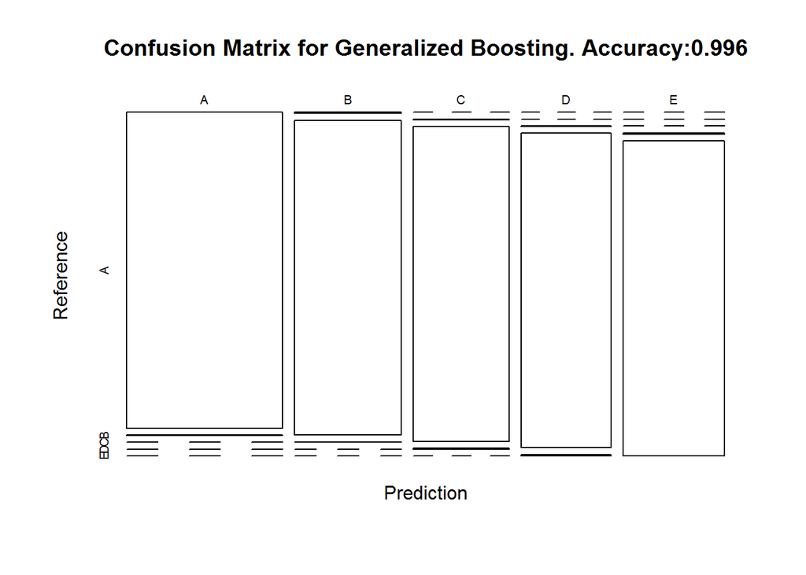

```r
plot(conmatgbm$table, col = conmatgbm$byClass, main = paste0("Confusion Matrix for Generalized Boosting. Accuracy:",
    round(conmatgbm$overall["Accuracy"], 3)))
```

# Apply the prediction model based on the random forest algorith to the 20 test cases

```r
predtestrf <- predict(modrf, fin_testing)
predtestrf
```

```
##  1  2  3  4  5  6  7  8  9 10 11 12 13 14 15 16 17 18 19 20
##  B  A  B  A  A  E  D  B  A  A  B  C  B  A  E  E  A  B  B  B
## Levels: A B C D E
```